# CIS8392 Course Project - Final

Catresa Barlow and Wan-Ting Tsai

5/1/2019

# Team Members

Catresa Barlow & Wan-Ting Tsai

# Business Context

E-cigarettes entered the US markets in 2007 (Preventing Tobacco Addiction Foundation, 2019) and use among youth and young adults has increased steadily since the product’s introduction (Office of the Surgeon General, 2016). Sweet flavors like candy apple, bubble gum, marshmallow, cherry cola, smores, chocolate, orange soda, and taffy entice young people to try these products. Online availability of flavored tobacco products makes these products easily accessible by minors (Preventing Tobacco Addiction Foundation, 2019).

Tobacco use among youth and young adults represents a major public health concern in the United States. “More than 95% of addicted smokers start before age 21”. Nicotine changes the receptor in the adolescent brain and creates lifelong addiction. (Preventing Tobacco Addiction Foundation, 2019). Although the use of conventional tobacco products by youth and young adults declined in recent decades, the Centers for Disease Control reports an increase in the use of “emerging tobacco products” like e-cigarettes among this population (Office of the Surgeon General, 2016).

# Problem Description

Tobacco companies employ social media to market their products to youth and young adults. Cessation and prevention campaigns require an understanding of how this population communicates about and uses these products. A key challenge for surveillance of the products and understanding their patterns of use is the diverse and nonstandard nomenclature for the devices (Alexander et al. 2016). These devices are referred to, by the companies themselves, and by consumers, as “e-cigarettes,” “e-cigs,” “cigalikes,” “e-hookahs,” “mods,” “vape pens,” “vapes,” and “tank systems.”

We hope to gain insight into tobacco marketing and patterns of use by analyzing social media platforms. Our project focuses on smoking among youth and young adults, and we believe Reddit is a platform used by this group. We wish to learn how tobacco companies communicate with this population and how this population communicates among itself on the subject of e-cigarettes.

# Data Summary, Exploration, and Discussion

Our team used the RedditExtractoR API to collect our data. We extracted post and comments from subreddits using the following keywords - “vape”, “e-cigarettes”, “vaping”, “juul”, “e-cig”.Our dataset contains 364k rows and 18 columns.

##Load Data

```r
reddit_comments <- read_csv("reddit_data.csv")
#check for unique rows
reddit_comments <- unique(reddit_comments)

head(reddit_comments)
```

```
## # A tibble: 6 x 18
##      id structure post_date comm_date num_comments subreddit upvote_prop
##   <dbl> <chr>     <chr>     <chr>            <dbl> <chr>           <dbl>
## 1     1 1         04-07-16  04-07-16           654 electron…        0.83
## 2     2 1_1       04-07-16  04-07-16           654 electron…        0.83
## 3     3 2         04-07-16  04-07-16           654 electron…        0.83
## 4     4 3         04-07-16  04-07-16           654 electron…        0.83
## 5     5 3_1       04-07-16  04-07-16           654 electron…        0.83
## 6     6 3_2       04-07-16  04-07-16           654 electron…        0.83
## # … with 11 more variables: post_score <dbl>, author <chr>, user <chr>,
## #   comment_score <dbl>, controversiality <dbl>, comment <chr>,
## #   title <chr>, post_text <chr>, link <chr>, domain <chr>, URL <chr>
```

```r
summary(reddit_comments)
```

```
##        id         structure          post_date          comm_date
##  Min.   :  1.0   Length:364467      Length:364467      Length:364467
##  1st Qu.: 78.0   Class :character   Class :character   Class :character
##  Median :172.0   Mode  :character   Mode  :character   Mode  :character
##  Mean   :196.7
##  3rd Qu.:309.0
##  Max.   :500.0
##   num_comments      subreddit          upvote_prop       post_score
##  Min.   :   83.0   Length:364467      Min.   :0.2900   Min.   :    0
##  1st Qu.:  332.0   Class :character   1st Qu.:0.8400   1st Qu.:   70
##  Median :  672.0   Mode  :character   Median :0.8800   Median :  128
##  Mean   :  845.5                      Mean   :0.8733   Mean   : 2910
##  3rd Qu.:  940.0                      3rd Qu.:0.9200   3rd Qu.:  593
##  Max.   :12751.0                      Max.   :1.0000   Max.   :97636
##     author              user           comment_score
##  Length:364467      Length:364467      Min.   : -195.00
##  Class :character   Class :character   1st Qu.:    1.00
##  Mode  :character   Mode  :character   Median :    1.00
##                                        Mean   :   11.63
##                                        3rd Qu.:    2.00
##                                        Max.   :17588.00
##  controversiality    comment             title
##  Min.   :0.00000   Length:364467      Length:364467
##  1st Qu.:0.00000   Class :character   Class :character
##  Median :0.00000   Mode  :character   Mode  :character
##  Mean   :0.01709
##  3rd Qu.:0.00000
##  Max.   :1.00000
##   post_text             link              domain
##  Length:364467      Length:364467      Length:364467
##  Class :character   Class :character   Class :character
##  Mode  :character   Mode  :character   Mode  :character
##
##
##
##      URL
##  Length:364467
##  Class :character
##  Mode  :character
##
##
##
```

##Pre-process Data

```r
#restructure data frame for comments
reddit_comment_df <- reddit_comments %>%
  mutate(thread_id = URL) %>%
  mutate(comment = str_replace_all(comment,  "<.+>", " ")) %>%
  mutate(comment = str_replace_all(comment,  "\\W", " ")) %>%
  mutate(comment_id = structure,
         comment_score = as.numeric(comment_score)) %>%
  select(subreddit, thread_id, comment_id, comment)

# restructure dataframe for post text
reddit_post_df <- reddit_comments %>%
  mutate(comment = post_text) %>%
  mutate(thread_id = URL) %>%
  mutate(comment = str_replace_all(comment,  "\\W", " ")) %>%
  mutate(comment_id = 0) %>%
  select(subreddit, thread_id,comment_id, comment) %>%
  na.omit() %>%
  unique()

#combine comments and post text
reddit_df <- rbind(reddit_post_df, reddit_comment_df)
```

##Explore Data

Explore Subreddit Threads

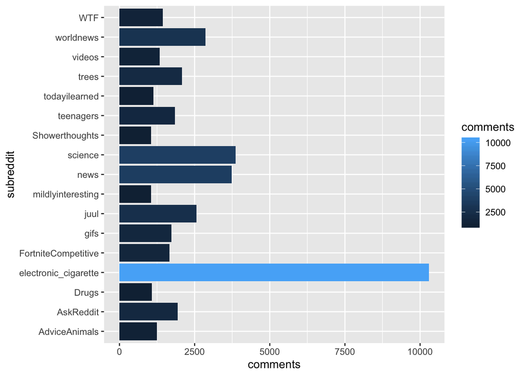

```r
#subreddit with more than 1000 comments
reddit_df %>%
  group_by(subreddit) %>%
  summarize(comments = n_distinct(comment_id)) %>%
  filter(comments > 1000) %>%
  ggplot(aes(subreddit, comments, fill = comments)) +
  geom_col() +
  coord_flip()
```

```r
#number of observations by subreddits
subreddits <- reddit_df %>%
  count(subreddit) %>%
  unique()

#number of subreddits
n_subreddits <- count(subreddits)

#number of threads
threads <-reddit_df %>%
  count(thread_id) %>%
  unique()

#display top 5 threads
top_n(threads, 5)
```

```
## # A tibble: 5 x 2
##   thread_id                                                               n
##   <chr>                                                               <int>
## 1 http://www.reddit.com/r/electronic_cigarette/comments/3b7iwl/vape_…   999
## 2 http://www.reddit.com/r/electronic_cigarette/comments/42m1g3/rocva…   995
## 3 http://www.reddit.com/r/electronic_cigarette/comments/4akauu/givea…   997
## 4 http://www.reddit.com/r/electronic_cigarette/comments/4nxk2x/givea…   999
## 5 http://www.reddit.com/r/teenagers/comments/azb1tj/put_it_down/?ref…  1096
```

```r
summary <- tibble(n_subreddits = n_subreddits, "   " ,n_threads = count(threads))
kable(summary, caption = "Number of subreddits and threads")
```

Number of subreddits and threads

| n_subreddits | " " | n_threads |
| --- | --- | --- |
| 171 |  | 1087 |

Explore Users

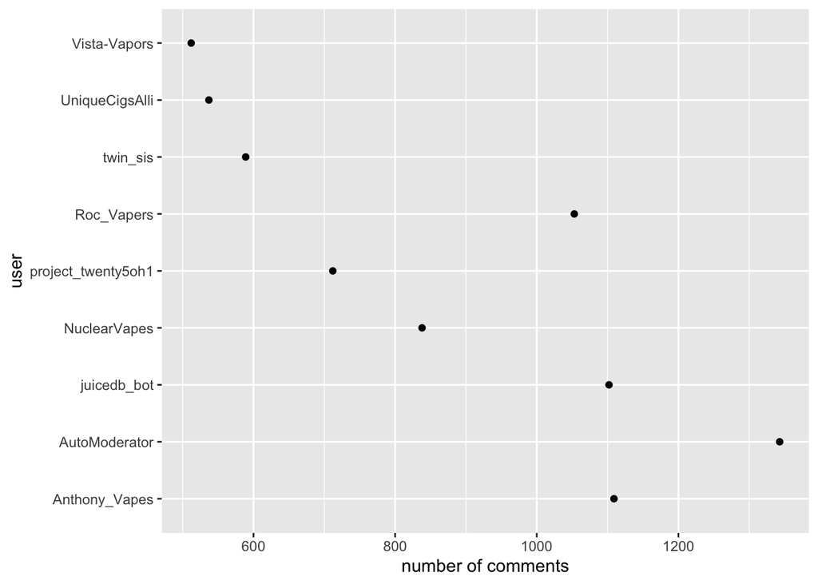

```r
#user network
user_df <- reddit_comments %>%
  group_by(user) %>%
  summarise(n = n()) %>%
  filter(n<500)

freq_users <- reddit_comments %>%
  anti_join(user_df, by = "user") %>%
  mutate(user = str_replace_all(user,  "\\Q[deleted]\\E", " ")) %>%
  group_by(user) %>%
  summarise(n = n())

freq_users %>%
  filter(user != " ") %>%
  ggplot((aes(x = n, y = user))) +
  geom_point() +
  xlab("number of comments") +
  ylab("user")
```

```r
#user network for smallest thread
target_df <- reddit_comments[which(reddit_comments$num_comments ==
                                     min(reddit_comments$num_comments)), ]
network_list <- target_df %>%
  user_network(include_author=FALSE, agg=TRUE)

network_list$plot
```

[interactive chart not shown]

##Tokenize Data

```r
#tokenize
tokens <- reddit_df %>%
  unnest_tokens(output = word, input = comment)

token_count <- tokens %>%
  count(word,
        sort = TRUE)

cleaned_tokens <- tokens %>%
  anti_join(get_stopwords())
#find numbers
nums <- cleaned_tokens %>%
  filter(str_detect(word, "^[0-9]")) %>%
  select(word) %>% unique()

#remove numbers
cleaned_tokens <- cleaned_tokens %>%
  anti_join(nums, by = "word")

length(unique(cleaned_tokens$word))
```

```
## [1] 92677
```

```r
rare <- cleaned_tokens %>%
  count(word) %>%
  filter(n<10) %>%
  select(word) %>%
  unique()

cleaned_tokens <- cleaned_tokens %>%
  anti_join(rare, by = "word")

letters <- cleaned_tokens %>%
  filter(str_length(word) < 3) %>%
  select(word) %>%
  unique()

cleaned_tokens <- cleaned_tokens %>%
  anti_join(letters, by = "word")

word_count <- cleaned_tokens %>%
  count(word,
        sort = TRUE)

word_by_subreddit <- cleaned_tokens %>%
  count(subreddit, word, sort= TRUE) %>%
  ungroup()

kable(head(word_count), caption = "word count")
```

word count

| word | n |
| --- | --- |
| thanks | 47673 |
| like | 45617 |
| just | 41910 |
| can | 36772 |
| one | 28552 |
| vaping | 28419 |

```r
kable(head(word_by_subreddit), caption = "word by subreddit")
```

word by subreddit

| subreddit | word | n |
| --- | --- | --- |
| electronic_cigarette | thanks | 45121 |
| electronic_cigarette | like | 24201 |
| electronic_cigarette | juice | 20874 |
| electronic_cigarette | just | 19910 |
| electronic_cigarette | giveaway | 18654 |
| electronic_cigarette | good | 17564 |

##Visualize Word Count

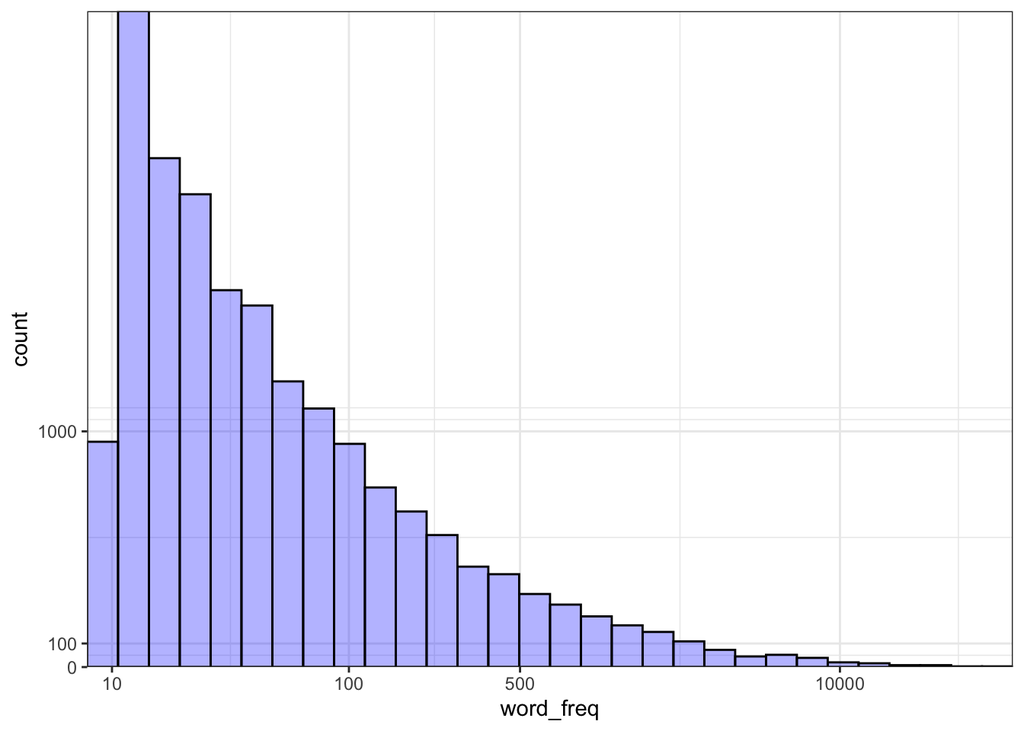

```r
#histogram
cleaned_tokens %>%
  count(word, sort = T) %>%
  rename(word_freq = n) %>%
  ggplot(aes(x=word_freq)) +
  geom_histogram(aes(y=..count..),
                 color="black",
                 fill="blue",
                 alpha=0.3) +
  scale_x_continuous(breaks=c(0:5,10,100,500,10e3),
                     trans="log1p",
                     expand=c(0,0)) +
  scale_y_continuous(breaks=c(0,100,1000,5e3,10e3,5e4,10e4,4e4),
                     expand=c(0,0)) +
  theme_bw()
```

#Natural Language Processing (NLP) Procedure Summary Our team used text mining techniques to surveil e-cigarettes young users who post content on Reddit. The goal is to understand how youth and young adults discuss topics of reasons for use, harm perception, frequency of use, flavorings, ad exposure, and quitting experience.

We employed sentiment analysis algorithms to analysis positive and negative words/sentences used to describe e-cigarette products. We also analyzed word frequencies to compare frequencies across different subreddits to discover which words occur most often in discussions and identify emerging products and trends.

##Sentiment Analysis For our sentiment analysis, we used the bing and afinn lexicon. We examined overall words as well as word by subreddits.

```r
comment_sentiment = cleaned_tokens %>%
  left_join(get_sentiments("bing")) %>%
  rename(bing = sentiment) %>%
  left_join(get_sentiments("afinn")) %>%
  rename(afinn = value)
```

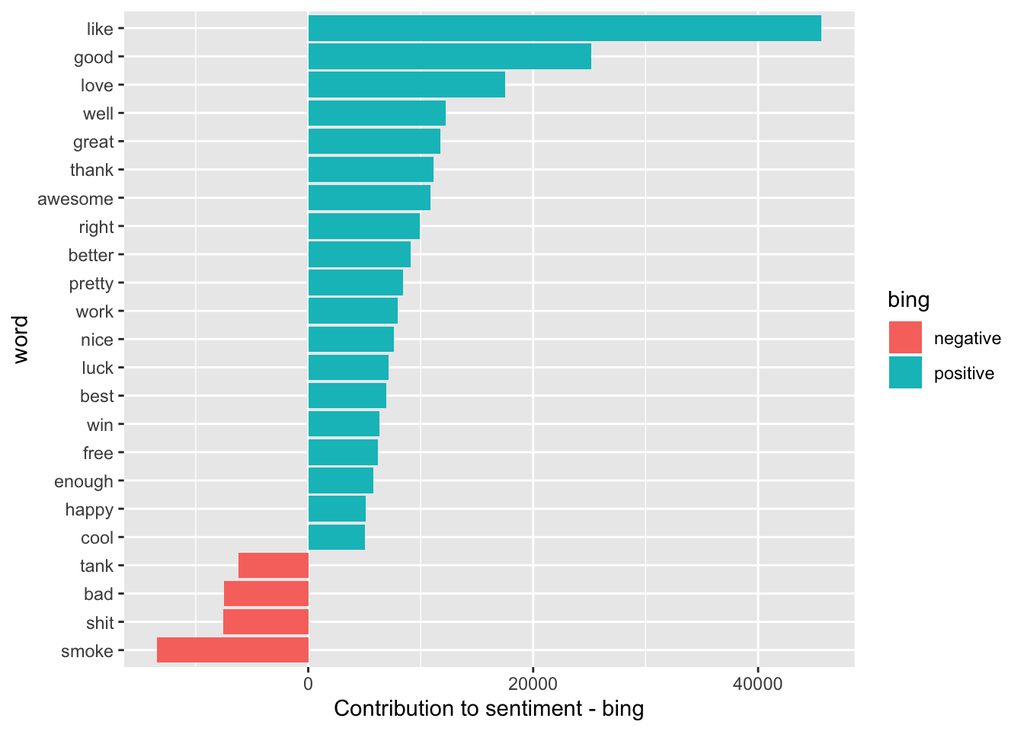

```r
#Sentiment Analysis - bing by word
bing_word_counts <- comment_sentiment %>%
  filter(!is.na(bing)) %>%
  count(word, bing, sort = TRUE)

bing_word_counts %>%
  filter(n > 5000) %>%
  mutate(n = ifelse(bing == "negative", -n, n)) %>%
  mutate(word = reorder(word, n)) %>%
  ggplot(aes(word, n, fill = bing)) +
  geom_col() +
  coord_flip() +
  labs(y = "Contribution to sentiment - bing")
```

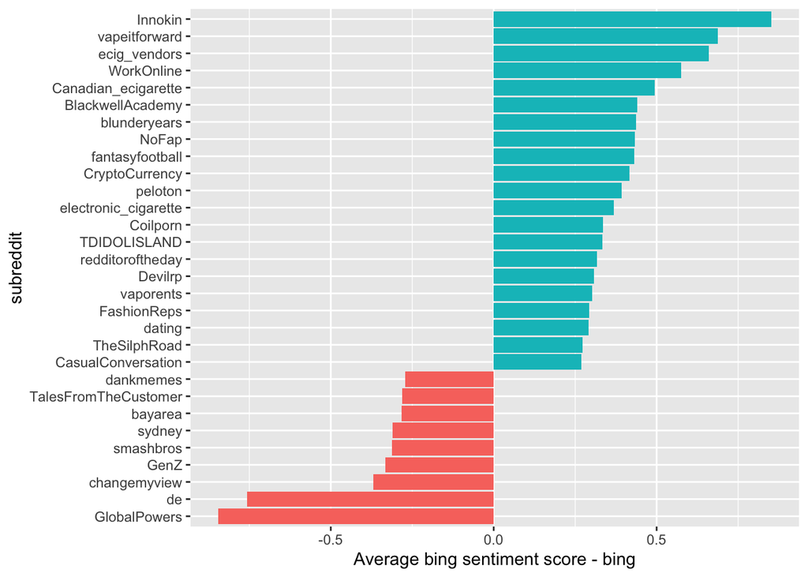

```r
#Sentiment Analysis by subreddit - bing
subreddit_sent_bing <- word_by_subreddit %>%
  inner_join(get_sentiments("bing"), by = "word") %>%
  mutate(sentiment = ifelse(sentiment == "negative", -1, 1)) %>%
  group_by(subreddit) %>%
  summarize(sentiment = sum(sentiment * n) / sum(n))

subreddit_sent_bing %>%
  top_n(30, abs(sentiment)) %>%
  mutate(subreddit = reorder(subreddit, sentiment)) %>%
  ggplot(aes(subreddit, sentiment, fill = sentiment > 0)) +
  geom_col(show.legend = FALSE) +
  coord_flip() +
  ylab("Average bing sentiment score - bing")
```

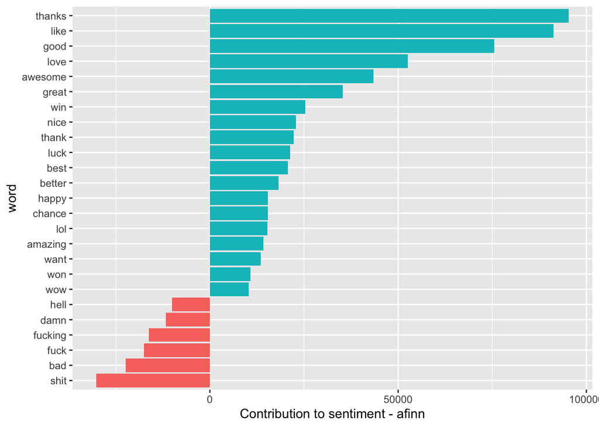

```r
#--------------------------------------------------------------
#Sentiment Analysis - afinn by word
afinn_word <- comment_sentiment %>%
  filter(!is.na(afinn)) %>%
  select(word, afinn) %>%
  group_by(word) %>%
  summarize(occurences = n(),
            contribution = sum(afinn))

options(scipen = 999)
afinn_word %>%
  top_n(25, abs(contribution)) %>%
  mutate(word = reorder(word, contribution)) %>%
  ggplot(aes(word, contribution, fill = contribution > 0)) +
  geom_col(show.legend = FALSE) +
  coord_flip() +
  labs(y = "Contribution to sentiment - afinn")
```

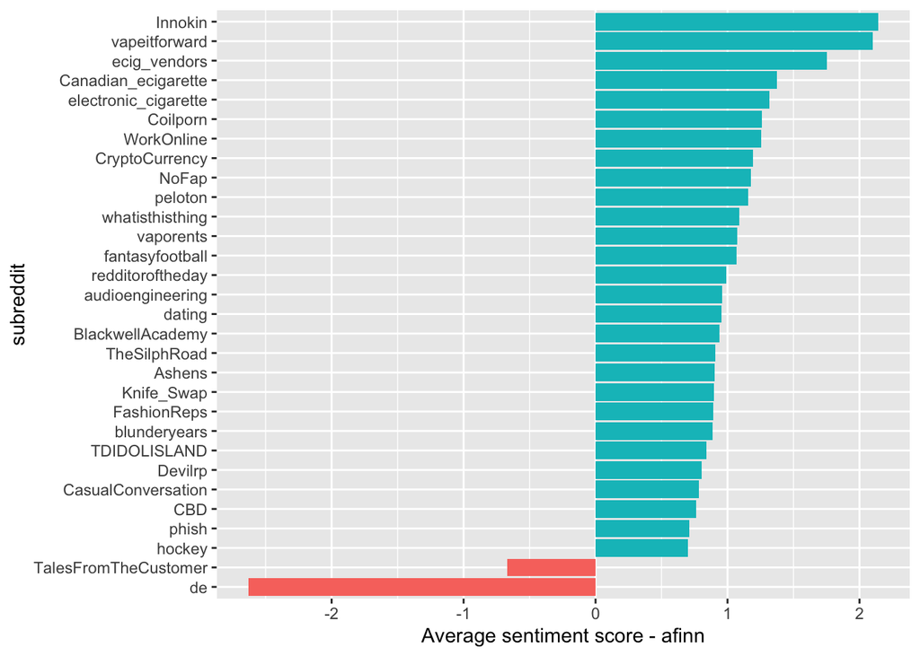

```r
#Sentiment Analysis - afinn by subreddit
subreddit_sentiment <- word_by_subreddit %>%
  inner_join(get_sentiments("afinn"), by = "word") %>%
  group_by(subreddit) %>%
  summarize(value = sum(value * n) / sum(n))

subreddit_sentiment %>%
  top_n(30, abs(value)) %>%
  mutate(subreddit = reorder(subreddit, value)) %>%
  ggplot(aes(subreddit, value, fill = value > 0)) +
  geom_col(show.legend = FALSE) +
  coord_flip() +
  ylab("Average sentiment score - afinn")
```

##Relationships Between Words

```r
#Tokenizing by bi-gram
bigrams <- reddit_df %>%
  unnest_tokens(bigram, comment,
                token = "ngrams", n = 2)

#bigrams %>% select(bigram)

# bigram counts:
#bigrams %>%
#  count(bigram, sort = TRUE)

# filtering n-grams
bigrams_separated <- bigrams %>%
  separate(bigram, c("word1", "word2"), sep = " ")

bigrams_filtered <- bigrams_separated %>%
  filter(!word1 %in% stop_words$word) %>%
  filter(!word2 %in% stop_words$word)

# new bigram counts:
bigrams_filtered %>%
  count(word1, word2, sort = TRUE)
```

```
## # A tibble: 528,477 x 3
##    word1   word2        n
##    <chr>   <chr>    <int>
##  1 <NA>    <NA>     24651
##  2 https   www       8360
##  3 http    www       7313
##  4 www     juicedb   4124
##  5 quit    smoking   3244
##  6 message compose   1609
##  7 awesome giveaway  1546
##  8 www     reddit    1509
##  9 max     vg        1491
## 10 started vaping    1382
## # … with 528,467 more rows
```

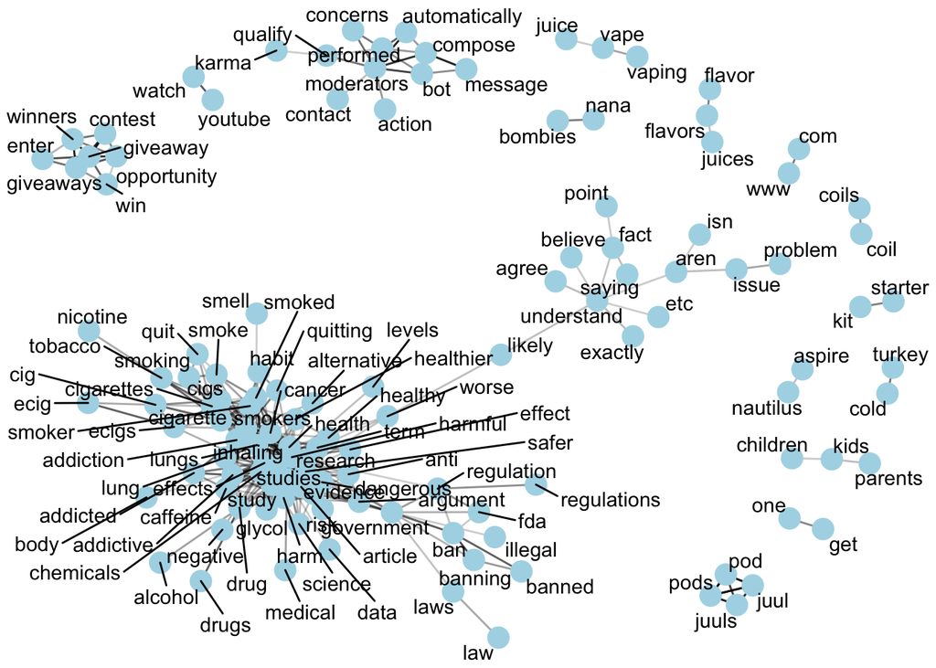

```r
# word correlation
uncommon <- cleaned_tokens %>%
  count(word) %>%
  filter(n<1000) %>%
  select(word) %>% unique()

word_cor = cleaned_tokens %>%
  anti_join(uncommon, by = "word") %>%
  widyr::pairwise_cor(word, thread_id) %>%
  filter(!is.na(correlation),
         correlation > .50)

# Visualizing the correlations
word_cor_plot <- word_cor %>%
  graph_from_data_frame() %>%
  ggraph(layout = "fr") +
  geom_edge_link(aes(edge_alpha = correlation), show.legend = FALSE) +
  geom_node_point(color = "lightblue", size = 5) +
  geom_node_text(aes(label = name), repel = TRUE) +
  theme_void()

word_cor_plot
```

```r
#-----------------------------------------------
#Tokenizing by tri-gram
trigrams <- reddit_df %>%
  unnest_tokens(trigram, comment,
                token = "ngrams", n = 3)
#trigrams %>% select(trigram)

# trigram counts:
#trigrams %>%
#  count(trigram, sort = TRUE)

# filtering n-grams
trigrams_separated <- trigrams %>%
  separate(trigram, c("word1", "word2", "word3"), sep = " ")

trigrams_filtered <- trigrams_separated %>%
  filter(!word1 %in% stop_words$word) %>%
  filter(!word2 %in% stop_words$word) %>%
  filter(!word3 %in% stop_words$word)

# new trigram counts:
trigrams_filtered %>%
  count(word1, word2, word3, sort = TRUE)
```

```
## # A tibble: 333,387 x 4
##    word1     word2        word3       n
##    <chr>     <chr>        <chr>   <int>
##  1 <NA>      <NA>         <NA>    43007
##  2 https     www          juicedb  4123
##  3 subreddit message      compose  1343
##  4 reviews   https        www      1310
##  5 reviews   official     site     1306
##  6 official  site         http     1187
##  7 10        comment      karma    1013
##  8 https     www          reddit    903
##  9 happy     independence day       814
## 10 site      http         www       726
## # … with 333,377 more rows
```

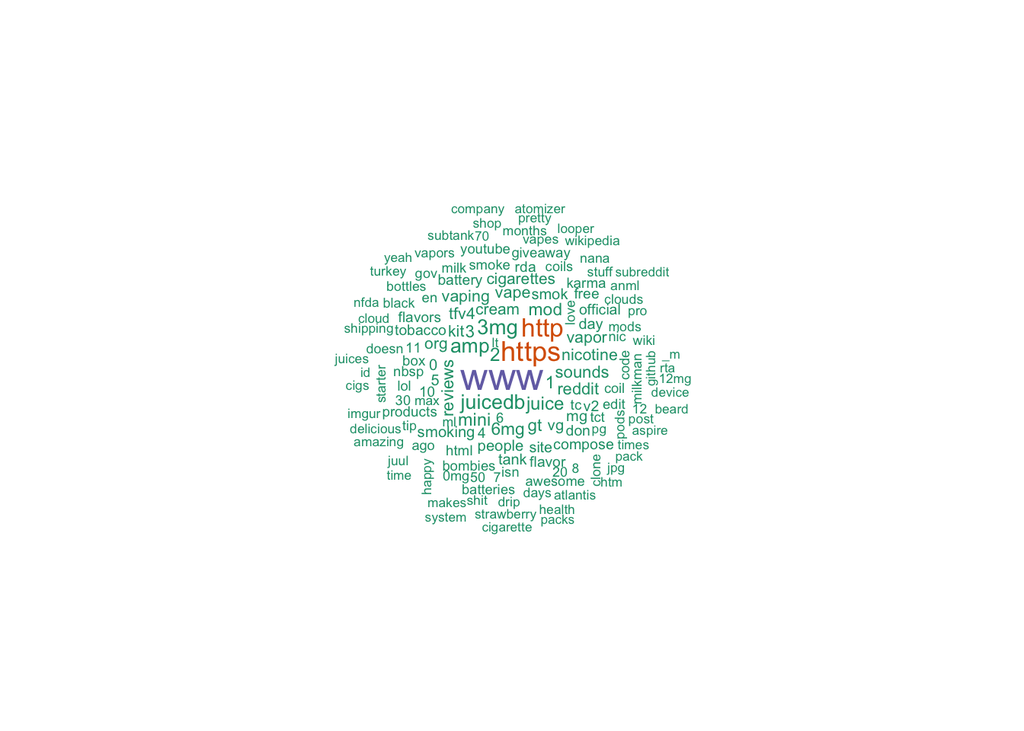

```r
#install.packages("wordcloud")
library(wordcloud)

# define a nice color palette
pal <- brewer.pal(8,"Dark2")

# plot the 150 most common words
trigrams_filtered %>%
  count(word3) %>%
  with(wordcloud(word3, n, random.order = FALSE, max.words = 150, colors=pal))
```

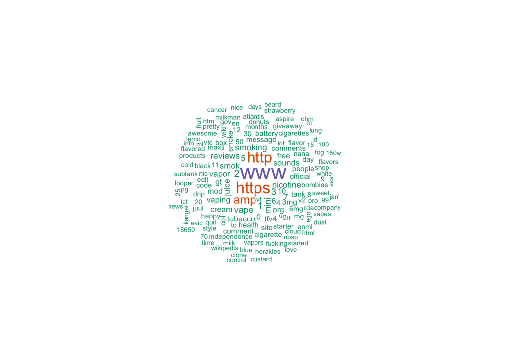

```r
trigrams_filtered %>%
  count(word2) %>%
  with(wordcloud(word2, n, random.order = FALSE, max.words = 150, colors=pal))
```

##Word and Document Frequency Word Frequency

```r
#Document(thread) Term Matrix
#Post Term Matrix

word_counts_by_thread_id <- cleaned_tokens %>%
  group_by(thread_id) %>%
  count(word, sort = TRUE)


review_dtm <- word_counts_by_thread_id %>%
  cast_dtm(thread_id, word, n)

review_dtm
```

```
## <<DocumentTermMatrix (documents: 1087, terms: 18587)>>
## Non-/sparse entries: 1263883/18940186
## Sparsity           : 94%
## Maximal term length: NA
## Weighting          : term frequency (tf)
```

```r
#tf-idf
tfidf <- word_counts_by_thread_id %>%
  bind_tf_idf(word, thread_id, n)

top_tfidf = tfidf %>%
  group_by(thread_id) %>%
  arrange(desc(tf_idf)) %>%
  top_n(3) %>% ungroup() %>%
  arrange(thread_id, -tf_idf)
#top_tfidf
```

Word Frequency by Subreddit

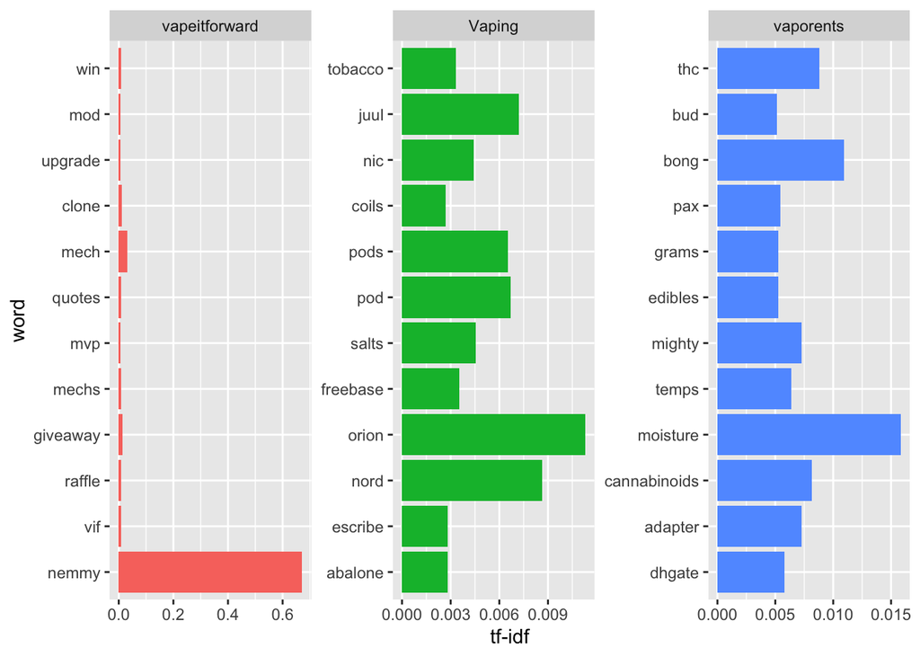

```r
tf_idf <- word_by_subreddit %>%
  bind_tf_idf(word, subreddit, n) %>%
  arrange(desc(tf_idf))

tf_idf %>%
  filter(str_detect(subreddit, "^vap|^Vap")) %>%
  group_by(subreddit) %>%
  top_n(12, tf_idf) %>%
  ungroup() %>%
  mutate(word = reorder(word, tf-idf)) %>%
  ggplot((aes(word, tf_idf, fill = subreddit))) +
  geom_col(show.legend = FALSE) +
  facet_wrap( ~ subreddit, scale = "free") +
  ylab("tf-idf") +
  coord_flip()
```

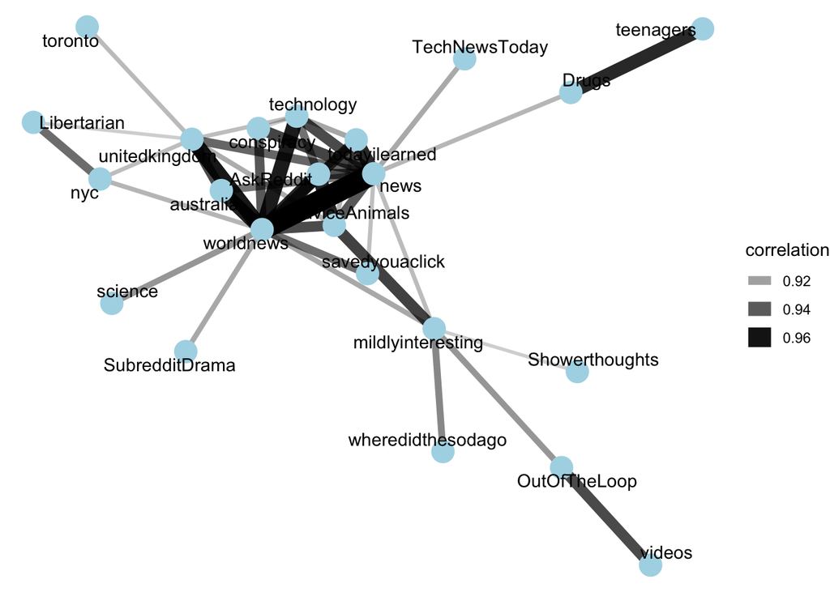

```r
subreddit_cors <- word_by_subreddit %>%
  pairwise_cor(subreddit, word, n, sort = TRUE)

set.seed(1231)

subreddit_cors %>%
  filter(correlation > .90) %>%
  graph_from_data_frame() %>%
  ggraph(layout = "fr") +
  geom_edge_link(aes(alpha = correlation, width = correlation)) +
  geom_node_point(size = 6, color = "lightblue") +
  geom_node_text(aes(label = name), repel = TRUE) +
  theme_void()
```

##Topic Modeling

```r
lda5 <- LDA(review_dtm, k = 5, control = list(seed = 1234))

topics <- terms(lda5, 100)
kable(head(topics))
```

| Topic 1 | Topic 2 | Topic 3 | Topic 4 | Topic 5 |
| --- | --- | --- | --- | --- |
| com | just | thanks | nicotine | like |
| juice | like | giveaway | smoking | vaping |
| www | can | love | people | just |
| https | get | good | cigarettes | can |
| http | people | awesome | vaping | one |
| name | don | thank | can | get |

#NLP result summary and discussion Sentiment Analysis  
We analyzed sentiment by word and subreddit and found that the majority of words in electronic cigarette posts and comments were positive. Users used words like “good”, “awesome”, “happy”, and “love” in discussions. Most subreddits also had an overall positive sentiment.

Relationships Between Words  
Bigram - We noted strong relationships between words such as “quit” and “smoking”, “awesome” and “giveaway”, “started” and “vaping”. More analysis is needed to gain information about the reasons/motivations for those who wish to quit. Also, we would like to understand the role of giveaways in encouraging young smokers to start smoking/vaping.

Trigram - The trigram analysis did not reveal any significant trend related to smoking or e-cigarettes. Additional analysis is required.

Word and Document Frequency - Our analysis revealed that words used frequently in discussions were “juice”, “vaping”, and “giveaway”. Young e-cigarette users are attracted to flavored products or (juice). Additional analysis is needed to understand how these products are discussed. Also, the frequency of the word “giveaway” suggests that free products are being offered often as an enticement for users to begin smoking.